# Biostat 203B Homework 5

Due Mar 22 @ 11:59PM

Author

Qianhui Du, UID: 006332140

## Predicting ICU duration

Using the ICU cohort `mimiciv_icu_cohort.rds` you built in Homework 4, develop at least three machine learning approaches (logistic regression with enet regularization, random forest, boosting, SVM, MLP, etc) plus a model stacking approach for predicting whether a patient’s ICU stay will be longer than 2 days. You should use the `los_long` variable as the outcome. You algorithms can use patient demographic information (gender, age at ICU `intime`, marital status, race), ICU admission information (first care unit), the last lab measurements before the ICU stay, and first vital measurements during ICU stay as features. You are welcome to use any feature engineering techniques you think are appropriate; but make sure to not use features that are not available at an ICU stay’s `intime`. For instance, `last_careunit` cannot be used in your algorithms.

1. Data preprocessing and feature engineering.
2. Partition data into 50% training set and 50% test set. Stratify partitioning according to `los_long`. For grading purpose, sort the data by `subject_id`, `hadm_id`, and `stay_id` and use the seed `203` for the initial data split. Below is the sample code.

```r
set.seed(203)

# sort
mimiciv_icu_cohort <- mimiciv_icu_cohort |>
  arrange(subject_id, hadm_id, stay_id)

data_split <- initial_split(
  mimiciv_icu_cohort,
  # stratify by los_long
  strata = "los_long",
  prop = 0.5
  )
```

3. Train and tune the models using the training set.
4. Compare model classification performance on the test set. Report both the area under ROC curve and accuracy for each machine learning algorithm and the model stacking. Interpret the results. What are the most important features in predicting long ICU stays? How do the models compare in terms of performance and interpretability?

#### Answer

##### Classification Trees

```r
library(GGally)
library(gtsummary)
library(keras)
library(ranger)
library(stacks)
library(tidyverse)
library(tidymodels)
library(xgboost)
library(doMC)
registerDoMC(cores = 8)

mimic_icu_cohort <- read_rds("mimiciv_shiny/mimic_icu_cohort.rds")

set.seed(203)

mimic_icu_cohort <- mimic_icu_cohort |>
  arrange(subject_id, hadm_id, stay_id) |>
  mutate(los_long = as.factor(los_long)) |>
  select(
    -dod,
    -1,
    -2,
    -3,
    -los,
    -discharge_location,
    -hospital_expire_flag
    )

data_split <- initial_split(
  mimic_icu_cohort,
  strata = "los_long",
  prop = 0.5
  )
train_set <- training(data_split)
test_set <- testing(data_split)
```

```r
mimic_recipe <-
  recipe(los_long ~ ., data = train_set) |>
  step_impute_mean(
    sodium,
    chloride,
    creatinine,
    potassium,
    glucose,
    hematocrit,
    wbc,
    bicarbonate,
    temperature_fahrenheit,
    non_invasive_blood_pressure_diastolic,
    respiratory_rate,
    non_invasive_blood_pressure_systolic,
    heart_rate, age_intime
    ) |>
  step_impute_mode(
    first_careunit,
    admission_type,
    admission_location,
    insurance,
    language,
    marital_status,
    race,
    gender
    ) |>
  step_naomit(all_predictors()) |>
  step_dummy(all_nominal_predictors()) |>
  step_zv(all_numeric_predictors()) |>
  step_normalize(all_numeric_predictors())
mimic_recipe
```

```
── Recipe ──────────────────────────────────────────────────────────────────────
```

```
── Inputs
```

```
Number of variables by role
```

```
outcome:    1
predictor: 22
```

```
── Operations
```

```
• Mean imputation for: sodium, chloride, creatinine, potassium, ...
```

```
• Mode imputation for: first_careunit and admission_type, ...
```

```
• Removing rows with NA values in: all_predictors()
```

```
• Dummy variables from: all_nominal_predictors()
```

```
• Zero variance filter on: all_numeric_predictors()
```

```
• Centering and scaling for: all_numeric_predictors()
```

```r
classtree_mod <- decision_tree(
  cost_complexity = tune(),
  tree_depth = tune(),
  min_n = 5,
  mode = "classification",
  engine = "rpart"
  )

tree_wf <- workflow() %>%
  add_recipe(mimic_recipe) %>%
  add_model(classtree_mod)
tree_wf
```

```
══ Workflow ════════════════════════════════════════════════════════════════════
Preprocessor: Recipe
Model: decision_tree()

── Preprocessor ────────────────────────────────────────────────────────────────
6 Recipe Steps

• step_impute_mean()
• step_impute_mode()
• step_naomit()
• step_dummy()
• step_zv()
• step_normalize()

── Model ───────────────────────────────────────────────────────────────────────
Decision Tree Model Specification (classification)

Main Arguments:
  cost_complexity = tune()
  tree_depth = tune()
  min_n = 5

Computational engine: rpart
```

```r
tree_grid <- grid_regular(cost_complexity(),
                          tree_depth(),
                          levels = c(100,5))

set.seed(203)

folds <- vfold_cv(train_set, v = 5)
folds
```

```
#  5-fold cross-validation
# A tibble: 5 × 2
  splits               id
  <list>               <chr>
1 <split [29272/7318]> Fold1
2 <split [29272/7318]> Fold2
3 <split [29272/7318]> Fold3
4 <split [29272/7318]> Fold4
5 <split [29272/7318]> Fold5
```

```r
tree_fit <- tree_wf %>%
  tune_grid(
    resamples = folds,
    grid = tree_grid,
    control = control_stack_grid()
    )
```

```
ℹ The workflow being saved contains a recipe, which is 5.67 Mb in ℹ memory. If
this was not intentional, please set the control setting ℹ `save_workflow =
FALSE`.
```

```r
tree_fit
```

```
# Tuning results
# 5-fold cross-validation
# A tibble: 5 × 5
  splits               id    .metrics             .notes           .predictions
  <list>               <chr> <list>               <list>           <list>
1 <split [29272/7318]> Fold1 <tibble [1,000 × 6]> <tibble [0 × 3]> <tibble>
2 <split [29272/7318]> Fold2 <tibble [1,000 × 6]> <tibble [0 × 3]> <tibble>
3 <split [29272/7318]> Fold3 <tibble [1,000 × 6]> <tibble [0 × 3]> <tibble>
4 <split [29272/7318]> Fold4 <tibble [1,000 × 6]> <tibble [0 × 3]> <tibble>
5 <split [29272/7318]> Fold5 <tibble [1,000 × 6]> <tibble [0 × 3]> <tibble>
```

```
# A tibble: 1,000 × 8
   cost_complexity tree_depth .metric  .estimator  mean     n std_err
             <dbl>      <int> <chr>    <chr>      <dbl> <int>   <dbl>
 1        1   e-10          1 accuracy binary     0.550     5 0.00338
 2        1   e-10          1 roc_auc  binary     0.539     5 0.00172
 3        1.23e-10          1 accuracy binary     0.550     5 0.00338
 4        1.23e-10          1 roc_auc  binary     0.539     5 0.00172
 5        1.52e-10          1 accuracy binary     0.550     5 0.00338
 6        1.52e-10          1 roc_auc  binary     0.539     5 0.00172
 7        1.87e-10          1 accuracy binary     0.550     5 0.00338
 8        1.87e-10          1 roc_auc  binary     0.539     5 0.00172
 9        2.31e-10          1 accuracy binary     0.550     5 0.00338
10        2.31e-10          1 roc_auc  binary     0.539     5 0.00172
   .config
   <chr>
 1 Preprocessor1_Model001
 2 Preprocessor1_Model001
 3 Preprocessor1_Model002
 4 Preprocessor1_Model002
 5 Preprocessor1_Model003
 6 Preprocessor1_Model003
 7 Preprocessor1_Model004
 8 Preprocessor1_Model004
 9 Preprocessor1_Model005
10 Preprocessor1_Model005
# ℹ 990 more rows
```

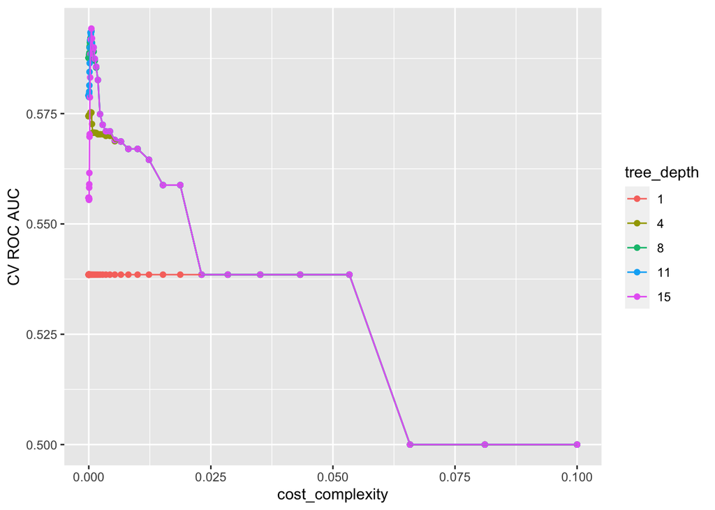

```r
tree_fit %>%
  collect_metrics() %>%
  print(width = Inf) %>%
  filter(.metric == "roc_auc") %>%
  mutate(tree_depth = as.factor(tree_depth)) %>%
  ggplot(mapping = aes(x = cost_complexity,
                       y = mean,
                       color = tree_depth)) +
  geom_point() +
  geom_line() +
  labs(x = "cost_complexity",
       y = "CV ROC AUC",
       color = "tree_depth")
```

```r
tree_fit %>%
  show_best("roc_auc")
```

```
# A tibble: 5 × 8
  cost_complexity tree_depth .metric .estimator  mean     n std_err .config
            <dbl>      <int> <chr>   <chr>      <dbl> <int>   <dbl> <chr>
1        0.000534         15 roc_auc binary     0.594     5 0.00457 Preprocesso…
2        0.000534          8 roc_auc binary     0.594     5 0.00672 Preprocesso…
3        0.000534         11 roc_auc binary     0.594     5 0.00460 Preprocesso…
4        0.000351         11 roc_auc binary     0.593     5 0.00279 Preprocesso…
5        0.000433         11 roc_auc binary     0.593     5 0.00438 Preprocesso…
```

```r
best_tree <- tree_fit %>%
  select_best("roc_auc")
best_tree
```

```
# A tibble: 1 × 3
  cost_complexity tree_depth .config
            <dbl>      <int> <chr>
1        0.000534         15 Preprocessor1_Model475
```

```r
final_wf <- tree_wf %>%
  finalize_workflow(best_tree)
final_wf
```

```
══ Workflow ════════════════════════════════════════════════════════════════════
Preprocessor: Recipe
Model: decision_tree()

── Preprocessor ────────────────────────────────────────────────────────────────
6 Recipe Steps

• step_impute_mean()
• step_impute_mode()
• step_naomit()
• step_dummy()
• step_zv()
• step_normalize()

── Model ───────────────────────────────────────────────────────────────────────
Decision Tree Model Specification (classification)

Main Arguments:
  cost_complexity = 0.000533669923120631
  tree_depth = 15
  min_n = 5

Computational engine: rpart
```

```r
final_fit <-
  final_wf %>%
  last_fit(data_split)
final_fit
```

```
# Resampling results
# Manual resampling
# A tibble: 1 × 6
  splits                id             .metrics .notes   .predictions .workflow
  <list>                <chr>          <list>   <list>   <list>       <list>
1 <split [36590/36591]> train/test sp… <tibble> <tibble> <tibble>     <workflow>
```

```r
final_fit %>%
  collect_metrics()
```

```
# A tibble: 2 × 4
  .metric  .estimator .estimate .config
  <chr>    <chr>          <dbl> <chr>
1 accuracy binary         0.577 Preprocessor1_Model1
2 roc_auc  binary         0.593 Preprocessor1_Model1
```

```r
library(rpart.plot)
final_tree <- extract_workflow(final_fit)
final_tree
```

```
══ Workflow [trained] ══════════════════════════════════════════════════════════
Preprocessor: Recipe
Model: decision_tree()

── Preprocessor ────────────────────────────────────────────────────────────────
6 Recipe Steps

• step_impute_mean()
• step_impute_mode()
• step_naomit()
• step_dummy()
• step_zv()
• step_normalize()

── Model ───────────────────────────────────────────────────────────────────────
n= 36590

node), split, n, loss, yval, (yprob)
      * denotes terminal node

    1) root 36590 17565 FALSE (0.51995081 0.48004919)
      2) admission_location_TRANSFER.FROM.HOSPITAL< 0.684698 28631 13042 FALSE (0.54447976 0.45552024)
        4) heart_rate< 0.6735811 22067  9578 FALSE (0.56595822 0.43404178)
          8) non_invasive_blood_pressure_systolic>=-1.116664 19429  8145 FALSE (0.58078131 0.41921869)
           16) age_intime< -0.6058538 4677  1676 FALSE (0.64165063 0.35834937)
             32) wbc< 0.5161395 4034  1356 FALSE (0.66385721 0.33614279) *
             33) wbc>=0.5161395 643   320 FALSE (0.50233281 0.49766719)
               66) glucose< -0.2844725 196    77 FALSE (0.60714286 0.39285714) *
               67) glucose>=-0.2844725 447   204 TRUE (0.45637584 0.54362416)
                134) sodium< 1.314121 434   204 TRUE (0.47004608 0.52995392)
                  268) temperature_fahrenheit>=-0.0273031 301   143 FALSE (0.52491694 0.47508306)
                    536) temperature_fahrenheit< 0.1518799 191    76 FALSE (0.60209424 0.39790576) *
                    537) temperature_fahrenheit>=0.1518799 110    43 TRUE (0.39090909 0.60909091) *
                  269) temperature_fahrenheit< -0.0273031 133    46 TRUE (0.34586466 0.65413534) *
                135) sodium>=1.314121 13     0 TRUE (0.00000000 1.00000000) *
           17) age_intime>=-0.6058538 14752  6469 FALSE (0.56148319 0.43851681)
             34) wbc< -0.3610386 5469  2171 FALSE (0.60303529 0.39696471)
               68) admission_type_OBSERVATION.ADMIT< 1.1443 4831  1858 FALSE (0.61540054 0.38459946)
                136) non_invasive_blood_pressure_diastolic>=-0.04875922 4200  1560 FALSE (0.62857143 0.37142857)
                  272) temperature_fahrenheit< 0.1877166 3871  1397 FALSE (0.63911134 0.36088866) *
```

[output cut: 13 more lines]

```
                     1112) chloride>=-0.1146154 284   125 FALSE (0.55985915 0.44014085)
                       2224) hematocrit>=-0.1273893 180    67 FALSE (0.62777778 0.37222222) *
                       2225) hematocrit< -0.1273893 104    46 TRUE (0.44230769 0.55769231) *
                     1113) chloride< -0.1146154 188    83 TRUE (0.44148936 0.55851064)
                       2226) first_careunit_Medical.Surgical.Intensive.Care.Unit..MICU.SICU.>=0.8557304 40    14 FALSE (0.65000000 0.35000000) *
                       2227) first_careunit_Medical.Surgical.Intensive.Care.Unit..MICU.SICU.< 0.8557304 148    57 TRUE (0.38513514 0.61486486) *
                    557) non_invasive_blood_pressure_diastolic< -0.04413105 48    15 TRUE (0.31250000 0.68750000) *
                  279) non_invasive_blood_pressure_systolic>=2.094101 15     2 TRUE (0.13333333 0.86666667) *
             35) wbc>=-0.3610386 9283  4298 FALSE (0.53700312 0.46299688)
               70) hematocrit>=-0.4730776 6529  2887 FALSE (0.55781896 0.44218104)
                140) race_Other< 0.9875013 5708  2448 FALSE (0.57112824 0.42887176)
                  280) temperature_fahrenheit< 0.1697982 4987  2078 FALSE (0.58331662 0.41668338)

...
and 152 more lines.
```

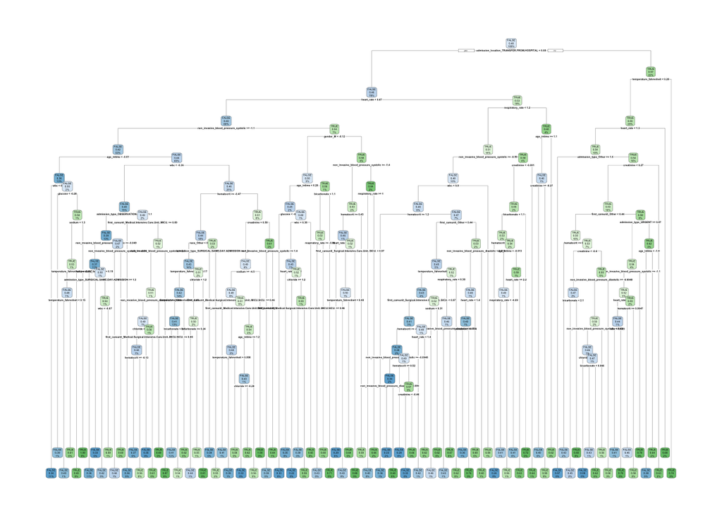

```r
final_tree %>%
  extract_fit_engine() %>%
  rpart.plot(roundint = FALSE)
```

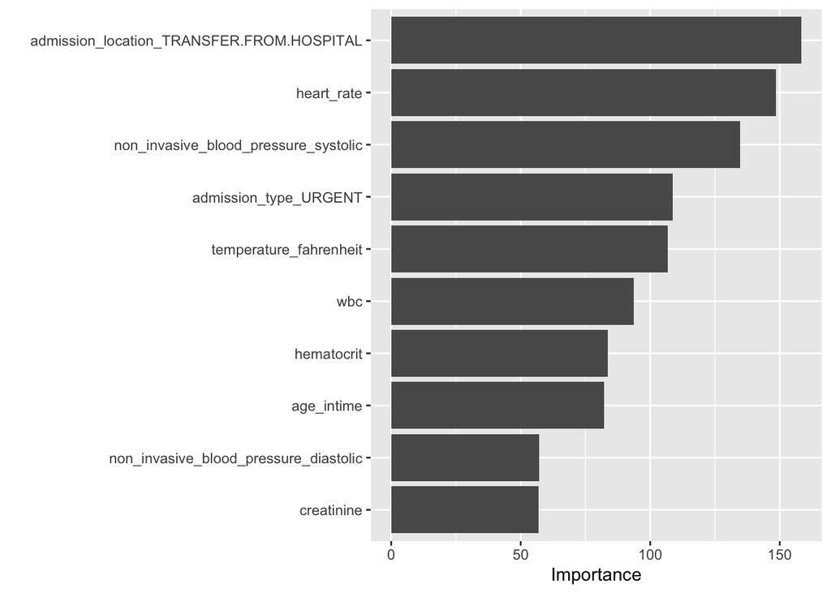

```r
library(vip)
final_tree %>%
  extract_fit_parsnip() %>%
  vip()
```

##### Random Forest for Classification

```r
library(GGally)
library(gtsummary)
library(keras)
library(ranger)
library(stacks)
library(tidyverse)
library(tidymodels)
library(xgboost)

mimic_icu_cohort <- read_rds("mimiciv_shiny/mimic_icu_cohort.rds")

set.seed(203)

mimic_icu_cohort <- mimic_icu_cohort |>
  arrange(subject_id, hadm_id, stay_id) |>
  mutate(
    los_long = as.factor(los_long)
    ) |>
  select(
    -dod,
    -1,
    -2,
    -3,
    -los,
    -discharge_location,
    -hospital_expire_flag
    )

data_split <- initial_split(
  mimic_icu_cohort,
  strata = "los_long",
  prop = 0.5
  )
train_set <- training(data_split)
test_set <- testing(data_split)
```

```r
mimic_recipe <-
  recipe(los_long ~ ., data = train_set) |>
  step_impute_mean(
    sodium,
    chloride,
    creatinine,
    potassium,
    glucose,
    hematocrit,
    wbc,
    bicarbonate,
    temperature_fahrenheit,
    non_invasive_blood_pressure_diastolic,
    respiratory_rate,
    non_invasive_blood_pressure_systolic,
    heart_rate,
    age_intime
    ) |>
  step_impute_mode(
    first_careunit,
    admission_type,
    admission_location,
    insurance,
    language,
    marital_status,
    race,
    gender
    ) |>
  step_zv(all_numeric_predictors())
mimic_recipe
```

```
── Recipe ──────────────────────────────────────────────────────────────────────
```

```
── Inputs
```

```
Number of variables by role
```

```
outcome:    1
predictor: 22
```

```
── Operations
```

```
• Mean imputation for: sodium, chloride, creatinine, potassium, ...
```

```
• Mode imputation for: first_careunit and admission_type, ...
```

```
• Zero variance filter on: all_numeric_predictors()
```

```r
rf_mod <-
  rand_forest(
    mode = "classification",
    mtry = tune(),
    trees = tune()
  ) %>%
  set_engine("ranger")
rf_mod
```

```
Random Forest Model Specification (classification)

Main Arguments:
  mtry = tune()
  trees = tune()

Computational engine: ranger
```

```r
rf_wf <- workflow() %>%
  add_recipe(mimic_recipe) %>%
  add_model(rf_mod)
rf_wf
```

```
══ Workflow ════════════════════════════════════════════════════════════════════
Preprocessor: Recipe
Model: rand_forest()

── Preprocessor ────────────────────────────────────────────────────────────────
3 Recipe Steps

• step_impute_mean()
• step_impute_mode()
• step_zv()

── Model ───────────────────────────────────────────────────────────────────────
Random Forest Model Specification (classification)

Main Arguments:
  mtry = tune()
  trees = tune()

Computational engine: ranger
```

```r
rf_grid <- grid_regular(
  trees(range = c(100L, 300L)),
  mtry(range = c(1L, 5L)),
  levels = c(3, 5)
  )
rf_grid
```

```
# A tibble: 15 × 2
   trees  mtry
   <int> <int>
 1   100     1
 2   200     1
 3   300     1
 4   100     2
 5   200     2
 6   300     2
 7   100     3
 8   200     3
 9   300     3
10   100     4
11   200     4
12   300     4
13   100     5
14   200     5
15   300     5
```

```r
set.seed(203)

folds <- vfold_cv(train_set, v = 5)
folds
```

```
#  5-fold cross-validation
# A tibble: 5 × 2
  splits               id
  <list>               <chr>
1 <split [29272/7318]> Fold1
2 <split [29272/7318]> Fold2
3 <split [29272/7318]> Fold3
4 <split [29272/7318]> Fold4
5 <split [29272/7318]> Fold5
```

```r
rf_fit <- rf_wf %>%
  tune_grid(
    resamples = folds,
    grid = rf_grid,
    control = control_stack_grid()
    )
```

```
ℹ The workflow being saved contains a recipe, which is 5.63 Mb in ℹ memory. If
this was not intentional, please set the control setting ℹ `save_workflow =
FALSE`.
```

```r
rf_fit
```

```
# Tuning results
# 5-fold cross-validation
# A tibble: 5 × 5
  splits               id    .metrics          .notes           .predictions
  <list>               <chr> <list>            <list>           <list>
1 <split [29272/7318]> Fold1 <tibble [30 × 6]> <tibble [0 × 3]> <tibble>
2 <split [29272/7318]> Fold2 <tibble [30 × 6]> <tibble [0 × 3]> <tibble>
3 <split [29272/7318]> Fold3 <tibble [30 × 6]> <tibble [0 × 3]> <tibble>
4 <split [29272/7318]> Fold4 <tibble [30 × 6]> <tibble [0 × 3]> <tibble>
5 <split [29272/7318]> Fold5 <tibble [30 × 6]> <tibble [0 × 3]> <tibble>
```

```
# A tibble: 30 × 8
    mtry trees .metric  .estimator  mean     n std_err .config
   <int> <int> <chr>    <chr>      <dbl> <int>   <dbl> <chr>
 1     1   100 accuracy binary     0.593     5 0.00288 Preprocessor1_Model01
 2     1   100 roc_auc  binary     0.632     5 0.00226 Preprocessor1_Model01
 3     1   200 accuracy binary     0.596     5 0.00323 Preprocessor1_Model02
 4     1   200 roc_auc  binary     0.640     5 0.00167 Preprocessor1_Model02
 5     1   300 accuracy binary     0.595     5 0.00269 Preprocessor1_Model03
 6     1   300 roc_auc  binary     0.641     5 0.00262 Preprocessor1_Model03
 7     2   100 accuracy binary     0.597     5 0.00197 Preprocessor1_Model04
 8     2   100 roc_auc  binary     0.634     5 0.00244 Preprocessor1_Model04
 9     2   200 accuracy binary     0.604     5 0.00324 Preprocessor1_Model05
10     2   200 roc_auc  binary     0.643     5 0.00353 Preprocessor1_Model05
# ℹ 20 more rows
```

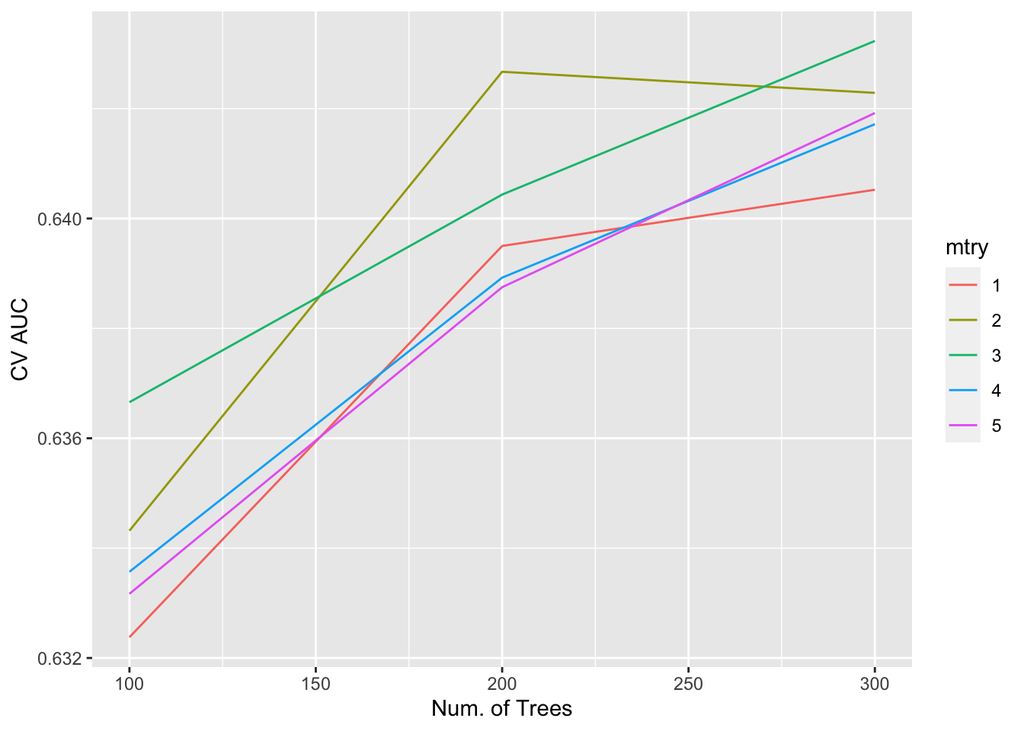

```r
rf_fit %>%
  collect_metrics() %>%
  print(width = Inf) %>%
  filter(.metric == "roc_auc") %>%
  mutate(mtry = as.factor(mtry)) %>%
  ggplot(mapping = aes(x = trees,
                       y = mean,
                       color = mtry)) +
  # geom_point() +
  geom_line() +
  labs(x = "Num. of Trees", y = "CV AUC")
```

```r
rf_fit %>%
  show_best("roc_auc")
```

```
# A tibble: 5 × 8
   mtry trees .metric .estimator  mean     n std_err .config
  <int> <int> <chr>   <chr>      <dbl> <int>   <dbl> <chr>
1     3   300 roc_auc binary     0.643     5 0.00313 Preprocessor1_Model09
2     2   200 roc_auc binary     0.643     5 0.00353 Preprocessor1_Model05
3     2   300 roc_auc binary     0.642     5 0.00323 Preprocessor1_Model06
4     5   300 roc_auc binary     0.642     5 0.00246 Preprocessor1_Model15
5     4   300 roc_auc binary     0.642     5 0.00308 Preprocessor1_Model12
```

```r
best_rf <- rf_fit %>%
  select_best("roc_auc")
best_rf
```

```
# A tibble: 1 × 3
   mtry trees .config
  <int> <int> <chr>
1     3   300 Preprocessor1_Model09
```

```r
final_wf <- rf_wf %>%
  finalize_workflow(best_rf)
final_wf
```

```
══ Workflow ════════════════════════════════════════════════════════════════════
Preprocessor: Recipe
Model: rand_forest()

── Preprocessor ────────────────────────────────────────────────────────────────
3 Recipe Steps

• step_impute_mean()
• step_impute_mode()
• step_zv()

── Model ───────────────────────────────────────────────────────────────────────
Random Forest Model Specification (classification)

Main Arguments:
  mtry = 3
  trees = 300

Computational engine: ranger
```

```r
final_fit <-
  final_wf %>%
  last_fit(data_split)
final_fit
```

```
# Resampling results
# Manual resampling
# A tibble: 1 × 6
  splits                id             .metrics .notes   .predictions .workflow
  <list>                <chr>          <list>   <list>   <list>       <list>
1 <split [36590/36591]> train/test sp… <tibble> <tibble> <tibble>     <workflow>
```

```r
final_fit %>%
  collect_metrics()
```

```
# A tibble: 2 × 4
  .metric  .estimator .estimate .config
  <chr>    <chr>          <dbl> <chr>
1 accuracy binary         0.601 Preprocessor1_Model1
2 roc_auc  binary         0.642 Preprocessor1_Model1
```

##### Boosting Tree for Classification

```r
library(GGally)
library(gtsummary)
library(keras)
library(ranger)
library(stacks)
library(tidyverse)
library(tidymodels)
library(xgboost)

mimic_icu_cohort <- read_rds("mimiciv_shiny/mimic_icu_cohort.rds")

set.seed(203)

mimic_icu_cohort <- mimic_icu_cohort |>
  arrange(subject_id, hadm_id, stay_id) |>
  mutate(
    los_long = as.factor(los_long)
    ) |>
  select(
    -dod,
    -1,
    -2,
    -3,
    -los,
    -discharge_location,
    -hospital_expire_flag
    )

data_split <- initial_split(
  mimic_icu_cohort,
  strata = "los_long",
  prop = 0.5
  )
train_set <- training(data_split)
test_set <- testing(data_split)
```

```r
mimic_recipe <-
  recipe(los_long ~ ., data = train_set) |>
  step_impute_mean(
    sodium,
    chloride,
    creatinine,
    potassium,
    glucose,
    hematocrit,
    wbc,
    bicarbonate,
    temperature_fahrenheit,
    non_invasive_blood_pressure_diastolic,
    respiratory_rate,
    non_invasive_blood_pressure_systolic,
    heart_rate,
    age_intime
    ) |>
  step_impute_mode(
    first_careunit,
    admission_type,
    admission_location,
    insurance,
    language,
    marital_status,
    race,
    gender
    ) |>
  step_dummy(all_nominal_predictors()) |>
  step_zv(all_numeric_predictors())
mimic_recipe
```

```
── Recipe ──────────────────────────────────────────────────────────────────────
```

```
── Inputs
```

```
Number of variables by role
```

```
outcome:    1
predictor: 22
```

```
── Operations
```

```
• Mean imputation for: sodium, chloride, creatinine, potassium, ...
```

```
• Mode imputation for: first_careunit and admission_type, ...
```

```
• Dummy variables from: all_nominal_predictors()
```

```
• Zero variance filter on: all_numeric_predictors()
```

```r
gb_mod <-
  boost_tree(
    mode = "classification",
    trees = 1000,
    tree_depth = tune(),
    learn_rate = tune()
  ) %>%
  set_engine("xgboost")
gb_mod
```

```
Boosted Tree Model Specification (classification)

Main Arguments:
  trees = 1000
  tree_depth = tune()
  learn_rate = tune()

Computational engine: xgboost
```

```r
gb_wf <- workflow() %>%
  add_recipe(mimic_recipe) %>%
  add_model(gb_mod)
gb_wf
```

```
══ Workflow ════════════════════════════════════════════════════════════════════
Preprocessor: Recipe
Model: boost_tree()

── Preprocessor ────────────────────────────────────────────────────────────────
4 Recipe Steps

• step_impute_mean()
• step_impute_mode()
• step_dummy()
• step_zv()

── Model ───────────────────────────────────────────────────────────────────────
Boosted Tree Model Specification (classification)

Main Arguments:
  trees = 1000
  tree_depth = tune()
  learn_rate = tune()

Computational engine: xgboost
```

```r
gb_grid <- grid_regular(
  tree_depth(range = c(1L, 3L)),
  learn_rate(range = c(-5, 2), trans = log10_trans()),
  levels = c(3, 10)
  )
gb_grid
```

```
# A tibble: 30 × 2
   tree_depth learn_rate
        <int>      <dbl>
 1          1  0.00001
 2          2  0.00001
 3          3  0.00001
 4          1  0.0000599
 5          2  0.0000599
 6          3  0.0000599
 7          1  0.000359
 8          2  0.000359
 9          3  0.000359
10          1  0.00215
# ℹ 20 more rows
```

```r
set.seed(203)

folds <- vfold_cv(train_set, v = 5)
folds
```

```
#  5-fold cross-validation
# A tibble: 5 × 2
  splits               id
  <list>               <chr>
1 <split [29272/7318]> Fold1
2 <split [29272/7318]> Fold2
3 <split [29272/7318]> Fold3
4 <split [29272/7318]> Fold4
5 <split [29272/7318]> Fold5
```

```r
gb_fit <- gb_wf %>%
  tune_grid(
    resamples = folds,
    grid = gb_grid,
    control = control_stack_grid()
    )
```

```
ℹ The workflow being saved contains a recipe, which is 5.66 Mb in ℹ memory. If
this was not intentional, please set the control setting ℹ `save_workflow =
FALSE`.
```

```r
gb_fit
```

```
# Tuning results
# 5-fold cross-validation
# A tibble: 5 × 5
  splits               id    .metrics          .notes           .predictions
  <list>               <chr> <list>            <list>           <list>
1 <split [29272/7318]> Fold1 <tibble [60 × 6]> <tibble [0 × 3]> <tibble>
2 <split [29272/7318]> Fold2 <tibble [60 × 6]> <tibble [0 × 3]> <tibble>
3 <split [29272/7318]> Fold3 <tibble [60 × 6]> <tibble [0 × 3]> <tibble>
4 <split [29272/7318]> Fold4 <tibble [60 × 6]> <tibble [0 × 3]> <tibble>
5 <split [29272/7318]> Fold5 <tibble [60 × 6]> <tibble [0 × 3]> <tibble>
```

```
# A tibble: 60 × 8
   tree_depth learn_rate .metric  .estimator  mean     n std_err
        <int>      <dbl> <chr>    <chr>      <dbl> <int>   <dbl>
 1          1  0.00001   accuracy binary     0.550     5 0.00338
 2          1  0.00001   roc_auc  binary     0.539     5 0.00172
 3          2  0.00001   accuracy binary     0.559     5 0.00259
 4          2  0.00001   roc_auc  binary     0.561     5 0.00307
 5          3  0.00001   accuracy binary     0.564     5 0.00312
 6          3  0.00001   roc_auc  binary     0.575     5 0.00487
 7          1  0.0000599 accuracy binary     0.550     5 0.00338
 8          1  0.0000599 roc_auc  binary     0.539     5 0.00172
 9          2  0.0000599 accuracy binary     0.559     5 0.00255
10          2  0.0000599 roc_auc  binary     0.571     5 0.00440
   .config
   <chr>
 1 Preprocessor1_Model01
 2 Preprocessor1_Model01
 3 Preprocessor1_Model02
 4 Preprocessor1_Model02
 5 Preprocessor1_Model03
 6 Preprocessor1_Model03
 7 Preprocessor1_Model04
 8 Preprocessor1_Model04
 9 Preprocessor1_Model05
10 Preprocessor1_Model05
# ℹ 50 more rows
```

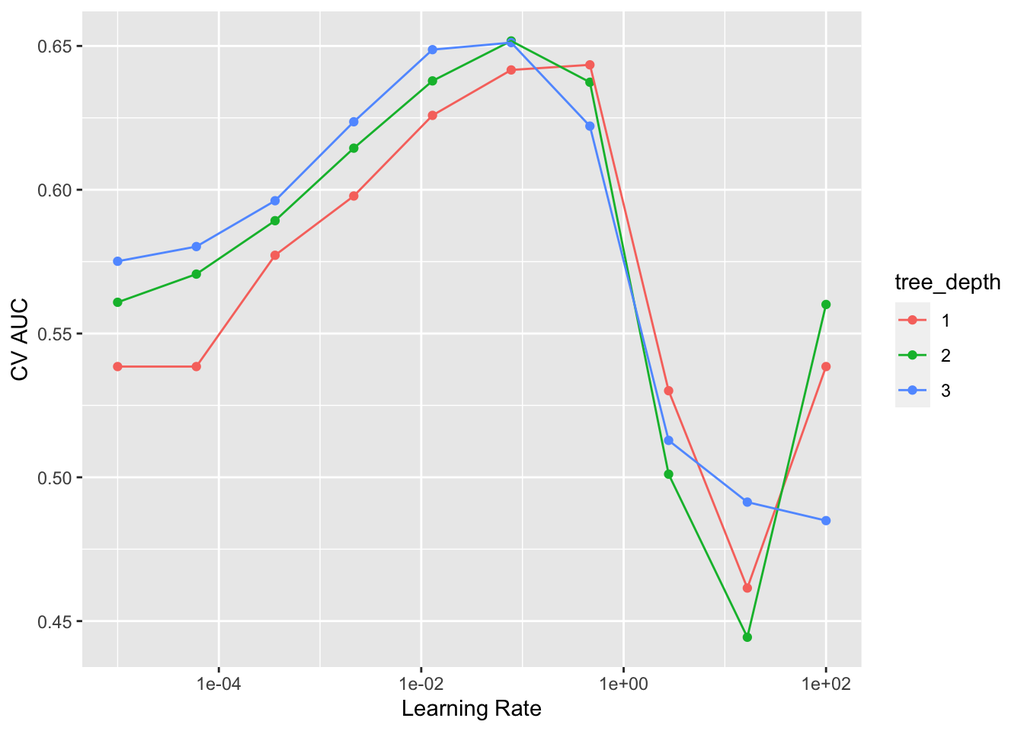

```r
gb_fit %>%
  collect_metrics() %>%
  print(width = Inf) %>%
  filter(.metric == "roc_auc") %>%
  mutate(tree_depth = as.factor(tree_depth)) %>%
  ggplot(mapping = aes(x = learn_rate,
                       y = mean,
                       color = tree_depth)) +
  geom_point() +
  geom_line() +
  labs(x = "Learning Rate", y = "CV AUC") +
  scale_x_log10()
```

```r
gb_fit %>%
  show_best("roc_auc")
```

```
# A tibble: 5 × 8
  tree_depth learn_rate .metric .estimator  mean     n std_err .config
       <int>      <dbl> <chr>   <chr>      <dbl> <int>   <dbl> <chr>
1          2     0.0774 roc_auc binary     0.652     5 0.00232 Preprocessor1_Mo…
2          3     0.0774 roc_auc binary     0.651     5 0.00297 Preprocessor1_Mo…
3          3     0.0129 roc_auc binary     0.649     5 0.00338 Preprocessor1_Mo…
4          1     0.464  roc_auc binary     0.643     5 0.00257 Preprocessor1_Mo…
5          1     0.0774 roc_auc binary     0.642     5 0.00277 Preprocessor1_Mo…
```

```r
best_gb <- gb_fit %>%
  select_best("roc_auc")
best_gb
```

```
# A tibble: 1 × 3
  tree_depth learn_rate .config
       <int>      <dbl> <chr>
1          2     0.0774 Preprocessor1_Model17
```

```r
final_wf <- gb_wf %>%
  finalize_workflow(best_gb)
final_wf
```

```
══ Workflow ════════════════════════════════════════════════════════════════════
Preprocessor: Recipe
Model: boost_tree()

── Preprocessor ────────────────────────────────────────────────────────────────
4 Recipe Steps

• step_impute_mean()
• step_impute_mode()
• step_dummy()
• step_zv()

── Model ───────────────────────────────────────────────────────────────────────
Boosted Tree Model Specification (classification)

Main Arguments:
  trees = 1000
  tree_depth = 2
  learn_rate = 0.0774263682681127

Computational engine: xgboost
```

```r
final_fit <-
  final_wf %>%
  last_fit(data_split)
final_fit
```

```
# Resampling results
# Manual resampling
# A tibble: 1 × 6
  splits                id             .metrics .notes   .predictions .workflow
  <list>                <chr>          <list>   <list>   <list>       <list>
1 <split [36590/36591]> train/test sp… <tibble> <tibble> <tibble>     <workflow>
```

```r
final_fit %>%
  collect_metrics()
```

```
# A tibble: 2 × 4
  .metric  .estimator .estimate .config
  <chr>    <chr>          <dbl> <chr>
1 accuracy binary         0.606 Preprocessor1_Model1
2 roc_auc  binary         0.650 Preprocessor1_Model1
```

##### Model Stacking

```r
mimic_model_st <-
  stacks() |>
  add_candidates(tree_fit) |>
  add_candidates(rf_fit) |>
  add_candidates(gb_fit) |>
  blend_predictions(
    penalty = 10^(-6:2),
    metrics = c("roc_auc", "accuracy")
    ) |>
  fit_members()
mimic_model_st
```

```
── A stacked ensemble model ─────────────────────────────────────


Out of 123 possible candidate members, the ensemble retained 10.

Penalty: 0.01.

Mixture: 1.


The 10 highest weighted member classes are:
```

```
# A tibble: 10 × 3
   member                 type         weight
   <chr>                  <chr>         <dbl>
 1 .pred_TRUE_gb_fit_1_18 boost_tree  1.12
 2 .pred_TRUE_gb_fit_1_17 boost_tree  1.07
 3 .pred_TRUE_rf_fit_1_05 rand_forest 0.833
 4 .pred_TRUE_rf_fit_1_09 rand_forest 0.790
 5 .pred_TRUE_rf_fit_1_07 rand_forest 0.273
 6 .pred_TRUE_rf_fit_1_15 rand_forest 0.269
 7 .pred_TRUE_gb_fit_1_19 boost_tree  0.210
 8 .pred_TRUE_gb_fit_1_21 boost_tree  0.0922
 9 .pred_TRUE_rf_fit_1_12 rand_forest 0.0104
10 .pred_TRUE_rf_fit_1_02 rand_forest 0.00421
```

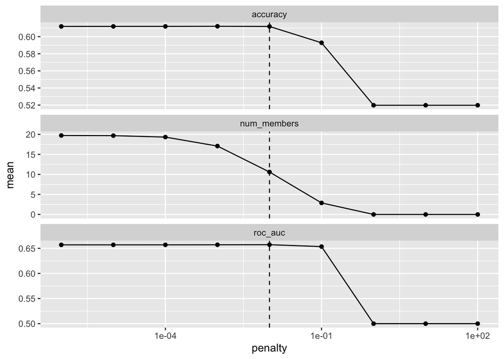

```r
autoplot(mimic_model_st)
```

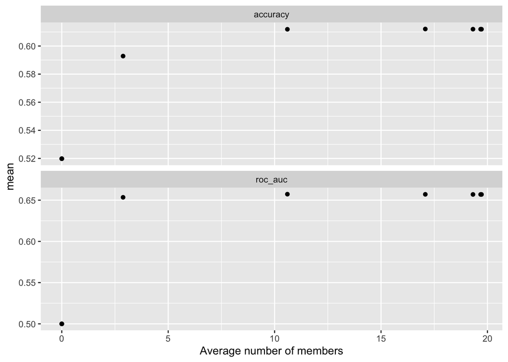

```r
autoplot(mimic_model_st, type = "members")
```

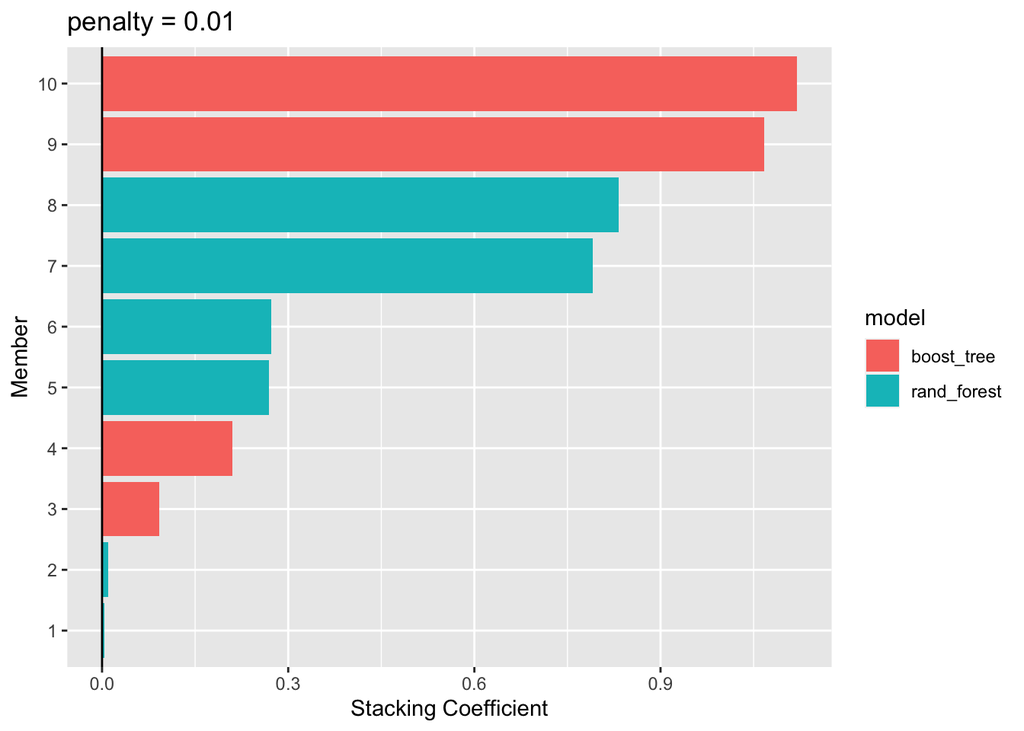

```r
autoplot(mimic_model_st, type = "weights")
```

```r
collect_parameters(mimic_model_st, "rf_fit")
```

```
# A tibble: 15 × 5
   member       mtry trees terms                     coef
   <chr>       <int> <int> <chr>                    <dbl>
 1 rf_fit_1_01     1   100 .pred_TRUE_rf_fit_1_01 0
 2 rf_fit_1_02     1   200 .pred_TRUE_rf_fit_1_02 0.00421
 3 rf_fit_1_03     1   300 .pred_TRUE_rf_fit_1_03 0
 4 rf_fit_1_04     2   100 .pred_TRUE_rf_fit_1_04 0
 5 rf_fit_1_05     2   200 .pred_TRUE_rf_fit_1_05 0.833
 6 rf_fit_1_06     2   300 .pred_TRUE_rf_fit_1_06 0
 7 rf_fit_1_07     3   100 .pred_TRUE_rf_fit_1_07 0.273
 8 rf_fit_1_08     3   200 .pred_TRUE_rf_fit_1_08 0
 9 rf_fit_1_09     3   300 .pred_TRUE_rf_fit_1_09 0.790
10 rf_fit_1_10     4   100 .pred_TRUE_rf_fit_1_10 0
11 rf_fit_1_11     4   200 .pred_TRUE_rf_fit_1_11 0
12 rf_fit_1_12     4   300 .pred_TRUE_rf_fit_1_12 0.0104
13 rf_fit_1_13     5   100 .pred_TRUE_rf_fit_1_13 0
14 rf_fit_1_14     5   200 .pred_TRUE_rf_fit_1_14 0
15 rf_fit_1_15     5   300 .pred_TRUE_rf_fit_1_15 0.269
```

```r
mimic_pred <- test_set %>%
  bind_cols(predict(mimic_model_st, ., type = "prob")) %>%
  print(width = Inf)
```

```
# A tibble: 36,591 × 25
   first_careunit                                   admission_type
   <fct>                                            <fct>
 1 Medical Intensive Care Unit (MICU)               EW EMER.
 2 Surgical Intensive Care Unit (SICU)              EW EMER.
 3 Surgical Intensive Care Unit (SICU)              Other
 4 Medical/Surgical Intensive Care Unit (MICU/SICU) EW EMER.
 5 Cardiac Vascular Intensive Care Unit (CVICU)     SURGICAL SAME DAY ADMISSION
 6 Other                                            EW EMER.
 7 Medical Intensive Care Unit (MICU)               EW EMER.
 8 Medical Intensive Care Unit (MICU)               EW EMER.
 9 Other                                            URGENT
10 Other                                            URGENT
   admission_location     insurance language marital_status race  gender sodium
   <fct>                  <chr>     <chr>    <chr>          <fct> <chr>   <dbl>
```

[output cut: 59 more lines]

```r
yardstick::roc_auc(
  mimic_pred,
  truth = los_long,
  contains(".pred_FALSE")
  )
```

```
# A tibble: 1 × 3
  .metric .estimator .estimate
  <chr>   <chr>          <dbl>
1 roc_auc binary         0.656
```

```r
mimic_acc <- test_set %>%
  bind_cols(predict(mimic_model_st, new_data = test_set)) %>%
  print(width = Inf)
```

```
# A tibble: 36,591 × 24
   first_careunit                                   admission_type
   <fct>                                            <fct>
 1 Medical Intensive Care Unit (MICU)               EW EMER.
 2 Surgical Intensive Care Unit (SICU)              EW EMER.
 3 Surgical Intensive Care Unit (SICU)              Other
 4 Medical/Surgical Intensive Care Unit (MICU/SICU) EW EMER.
 5 Cardiac Vascular Intensive Care Unit (CVICU)     SURGICAL SAME DAY ADMISSION
 6 Other                                            EW EMER.
 7 Medical Intensive Care Unit (MICU)               EW EMER.
 8 Medical Intensive Care Unit (MICU)               EW EMER.
 9 Other                                            URGENT
10 Other                                            URGENT
   admission_location     insurance language marital_status race  gender sodium
   <fct>                  <chr>     <chr>    <chr>          <fct> <chr>   <dbl>
```

[output cut: 59 more lines]

```r
yardstick::accuracy(
  mimic_acc,
  truth = los_long,
  estimate = .pred_class
  )
```

```
# A tibble: 1 × 3
  .metric  .estimator .estimate
  <chr>    <chr>          <dbl>
1 accuracy binary         0.611
```

##### Summary

The Boosting Tree had the highest performance, followed by the Random Forest, with the Decision Tree performing the lowest.

The Model Stacking showed the best results, indicating superior performance in predicting ICU stay lengths.

As performance increases from Decision Tree to Random Forest to Boosting Tree to Model Stacking, interpretability decreases.